# STAT/MATH 495: Problem Set 07

Kiryu Kawahata

2017-10-24

Information on the competition can be found [here](https://www.kaggle.com/c/GiveMeSomeCredit/data).

# Collaboration

Please indicate who you collaborated with on this assignment:

# Exploration

```r
#Visual analysis

kable(cor(train[c(4, 6, 7)], train$SeriousDlqin2yrs), title="Correlation with Count")
```

| age | -0.1153855 |
| --- | --- |
| DebtRatio | -0.0076021 |
| MonthlyIncome | NA |

```r
train_VOI <- train %>%
  select(DebtRatio, age, MonthlyIncome, SeriousDlqin2yrs)

null <- lm(SeriousDlqin2yrs ~ 1, data = train_VOI)
full <- lm(SeriousDlqin2yrs ~ ., data = train_VOI)
step(null, scope = list(lower = null, upper = full), direction = "both", steps = 3)
```

```
## Start:  AIC=-416192.8
## SeriousDlqin2yrs ~ 1
##
##                 Df Sum of Sq    RSS     AIC
## + age            1    81.995 7694.3 -330646
## + MonthlyIncome  1     3.032 7773.3 -329418
## <none>                       7776.3 -329373
## + DebtRatio      1     0.084 7776.2 -329372
##
## Step:  AIC=-418201.3
## SeriousDlqin2yrs ~ age
##
##                 Df Sum of Sq    RSS     AIC
## <none>                       9231.3 -418201
## - age            1   124.562 9355.9 -416193
## + MonthlyIncome  1     1.962 7692.3 -330674
## + DebtRatio      1     0.091 7694.2 -330645
```

```
##
## Call:
## lm(formula = SeriousDlqin2yrs ~ age, data = train_VOI)
##
## Coefficients:
## (Intercept)          age
##    0.168858    -0.001951
```

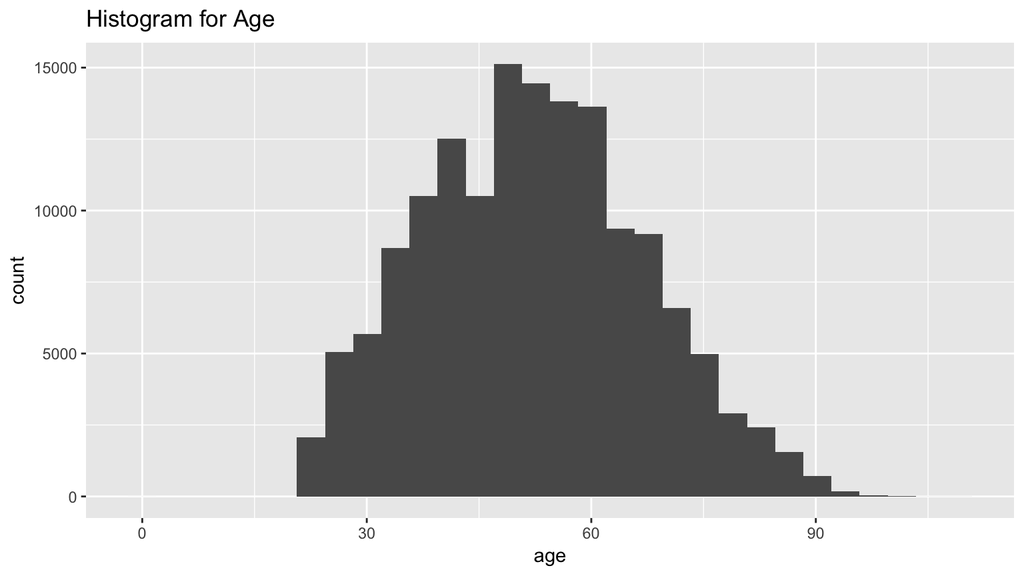

```r
ggplot(data = train, aes(x = age))+ geom_histogram() + theme(legend.position="none") + labs(title = "Histogram for Age")
```

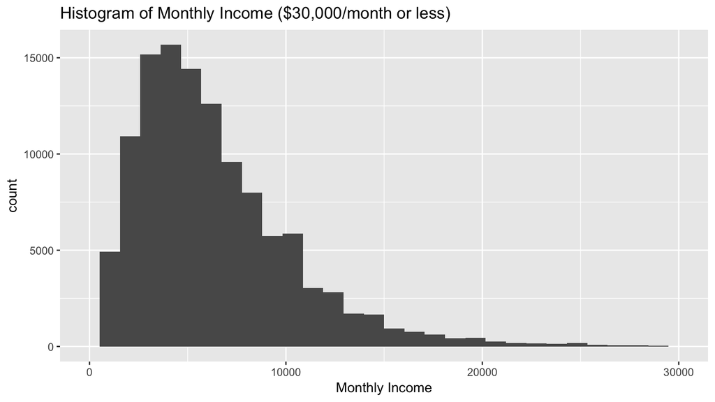

```r
ggplot(data = train, aes(x = MonthlyIncome))+ geom_histogram() + theme(legend.position="none") + labs(title = "Histogram of Monthly Income ($30,000/month or less)", x = "Monthly Income") + xlim(0, 30000)
```

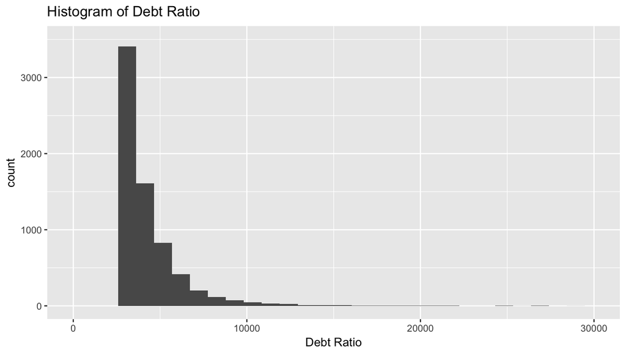

```r
ggplot(data = train, aes(x = DebtRatio))+ geom_histogram() + theme(legend.position="none") + labs(title = "Histogram of Debt Ratio", x = "Debt Ratio") + xlim(0, 30000) + ylim(0, 3500)
```

Having the greatest absolute correlation value, as well as being the most influential in stepwise regression, age appears to be the “strongest” predictor. In addition the distribution for age appears to be the most “normal” of the three. When looking at Monthly Income there seems to be a trend, however there is significantly lower representation of higher income levels in this training set. Only 792 of the train sample earn over 30000 a month. I’m not confident that filtering the training set will create accurate predictions for all incomes, so I’ve chosen age to be the sole predictor here.

# Build binary classifier

Build the binary classifier based on a single predictor variable: `DebtRatio`, `age`, or `MonthlyIncome`. Justify this choice.

```r
PS_formula <- as.formula(SeriousDlqin2yrs ~ age)
PS_Model <- glm(PS_formula, data = train, family = "binomial")

PS_Predictions <- PS_Model %>%
  broom::augment(newdata = test) %>%
  as_tibble() %>%
  mutate(P_hat = 1/(1 + exp(-.fitted)))

test_submission <- submission %>%
  mutate(Probability = PS_Predictions$P_hat)

write.csv(test_submission, "submission.csv", row.names = F)
```

# ROC curve

Based on the ultimate classifier you choose, plot a corresponding ROC curve.

```r
PS_augmented <- PS_Model %>%
  broom::augment() %>%
  as_tibble() %>%
  mutate(P_hat = 1/(1+exp(-.fitted)))

PS_pred <- prediction(predictions = PS_augmented$P_hat, labels = PS_augmented$SeriousDlqin2yrs)
PS_perf <- performance(PS_pred, "tpr","fpr")


auc <- as.numeric(performance(PS_pred,"auc")@y.values)
auc
```

```
## [1] 0.6352512
```

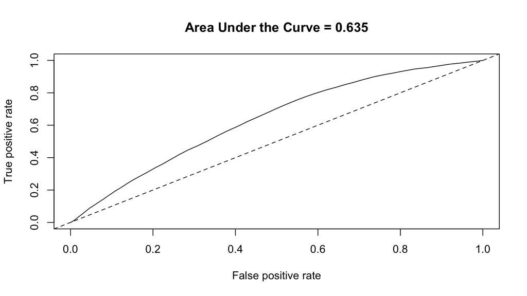

```r
plot(PS_perf, main=paste("Area Under the Curve =", round(auc, 3)))
abline(c(0, 1), lty=2)
```

# ROC curve for random guessing

Instead of using any predictor information as you did above, switch your predictions to random guesses and plot the resulting ROC curve.

```r
PS_random <- PS_Model %>%
  broom::augment() %>%
  as_tibble() %>%
  mutate(P_hat = 0.5)

PS_pred_Random <- prediction(predictions = PS_random$P_hat, labels = PS_random$SeriousDlqin2yrs)
perf_Rand <- performance(PS_pred_Random, "tpr","fpr")


auc_rand <- as.numeric(performance(PS_pred_Random,"auc")@y.values)
auc_rand
```

```
## [1] 0.5
```

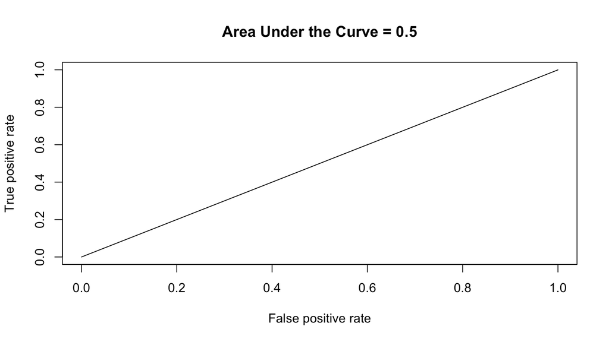

```r
plot(perf_Rand, main=paste("Area Under the Curve =", round(auc_rand, 3)))
```